# Week 3 Exercises

yufan_yin_week3: 29.9. - 5.10.2020

Also see in the page to my course diary: https://yufanyin.github.io/datavis-R/

```r
library(tidyverse)
```

## Exercise 1 Create categorical variable and use distinct()

### 1.1 Reading the data

```r
learning2019 <- read.csv(file = "D:/Users/yinyf/datavis-R/week0/learning2019_week3.csv", stringsAsFactors = TRUE)
learning19 <- learning2019 %>%
  mutate(studylength = as.numeric(studylength),
         writingcourse = as.numeric(writingcourse))

str(learning19)
```

```
## 'data.frame':    206 obs. of  17 variables:
##  $ 锘縩o          : int  1 2 3 4 5 6 7 8 9 10 ...
##  $ cluster        : int  3 2 1 1 3 1 2 2 1 3 ...
##  $ unref          : num  4 2 3 2 3 2.67 1 2.33 3 3.67 ...
##  $ deep           : num  3.5 4.25 3.75 4.25 3.25 3.5 4.25 4.25 4 4 ...
##  $ orga           : num  3.33 3 4.33 3.67 2.67 4 2.33 3.33 4 3.67 ...
##  $ blocks         : num  3.33 3.67 3.67 3 3.67 4 2.67 2.33 3.33 2.67 ...
##  $ procrastination: num  3.25 4.25 3.75 2.5 4.25 3.5 3.5 4.25 3.25 2.5 ...
##  $ perfectionism  : num  3.67 3.33 3.33 2.67 2.33 2.33 4 2.67 3 3.33 ...
##  $ innateability  : num  1 1.5 3 1.5 2.5 2 2 1 2.5 1 ...
##  $ ktransforming  : num  4 3.67 3.67 3.33 4 3.33 2 4.33 4 4.33 ...
##  $ productivity   : num  1.25 2 1.25 2.25 2.25 2.5 3 2.25 2.25 3.75 ...
##  $ gender         : int  2 2 2 2 2 2 2 2 2 2 ...
##  $ studentstatus  : int  1 1 1 1 1 1 1 1 1 2 ...
##  $ studylength    : num  39 51 3 3 15 3 3 3 3 3 ...
##  $ writingcourse  : num  2 3 4 0 0 11 0 0 44 35 ...
##  $ monthsamel     : int  2 2 NA 0 NA 2 4 NA 3 2 ...
##  $ faculty        : int  2 8 5 9 2 6 4 4 4 9 ...
```

### 1.2 Creating categorical variable

For my data, **studylength** is more suitable to be the categorical variable than **age**. It discribes how many months that students have studied in the university.

Cut the continuous variable **studylength** into a categorical variable **studylength_group**. Use ggplot2’s cutting function: `cut_number()` makes n groups with (approximately) equal number of observations.

Count observations by studylength group.

```r
library(ggplot2)
learning19 %>%
  mutate(score_group_test = cut_width(studylength, 12, boundary = 0)) %>% # range width is (max - min) / number of groups
  count(score_group_test)
```

```
##   score_group_test   n
## 1           [0,12] 102
## 2          (12,24]  47
## 3          (24,36]  19
## 4          (36,48]  14
## 5          (48,60]  16
## 6          (60,72]   5
## 7          (72,84]   2
## 8        (168,180]   1
```

```r
library(ggplot2)
learning19 %>%
  mutate(studylength_group = cut_number(studylength, 3)) %>% # each group has about 206 / 3 = 68 observations
  count(studylength_group)
```

```
##   studylength_group  n
## 1             [2,7] 71
## 2            (7,17] 67
## 3          (17,172] 68
```

Save the results with labels to the data.

```r
learning19 <- learning19 %>%
  mutate(studylength_group = cut_number(studylength, 3,
                                 labels = c('-7','8-17','18-')))
```

```r
learning19 %>%
  distinct(studylength_group)
```

```
##   studylength_group
## 1               18-
## 2                -7
## 3              8-17
```

## Exercise 2 Bar plots: geom_col()

The chunk below is supposed to produce a plot but it has some errors.

Fix the code to produce the right figure.

What happens if you use `geom_jitter()` instead of `geom_point()`?

**Hint**: Examine the code bit by bit: start by plotting just the scatter plot without `geom_smooth()`, and add the regression lines last.

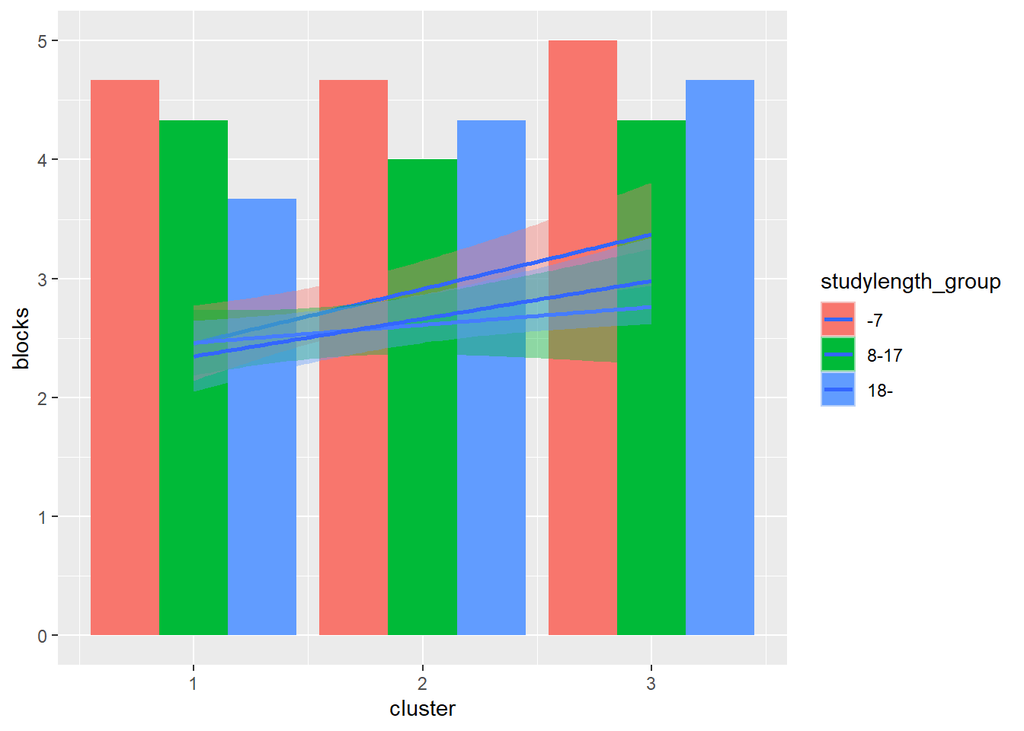

```r
learning19 %>%
  ggplot(aes(cluster, blocks, fill = studylength_group)) +
  geom_col(position = "dodge") +
  geom_smooth(method = "lm")
```

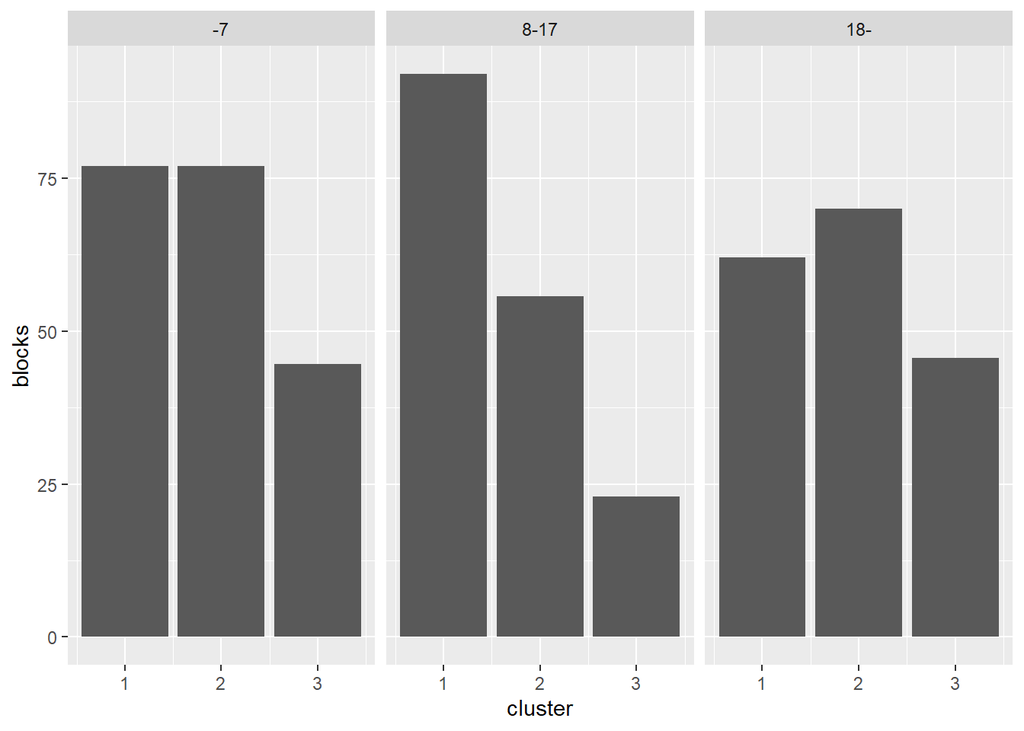

```r
learning19 %>%
  ggplot(aes(cluster, blocks)) +
  geom_col() +
  facet_wrap(~studylength_group)
```

## Exercise 3 Bar plots: geom_col()

### 3.1

Calculate the mean, standard deviation (sd), and number of observations (n) of **score on blocks by student profiles and study-length group**. Also calculate the standard error of the mean (by using sd and n). Save these into a new data frame (or tibble) named cluster_blocks_stats.

```r
cluster_blocks_stats <- learning19 %>%
  group_by(cluster, studylength_group, .drop = FALSE) %>% # there are no observations some of the combinations, but we don't drop them
  summarise(mean_blocks = mean(blocks),
            sd_blocks = sd(blocks),
            n = n()) %>%
  ungroup()
cluster_blocks_stats
```

```
## # A tibble: 9 x 5
##   cluster studylength_group mean_blocks sd_blocks     n
##     <int> <fct>                   <dbl>     <dbl> <int>
## 1       1 -7                       2.48     0.981    31
## 2       1 8-17                     2.49     0.870    37
## 3       1 18-                      2.38     0.685    26
## 4       2 -7                       2.85     0.922    27
## 5       2 8-17                     2.53     0.775    22
## 6       2 18-                      2.59     0.936    27
## 7       3 -7                       3.44     0.906    13
## 8       3 8-17                     2.88     1.15      8
## 9       3 18-                      3.04     0.845    15
```

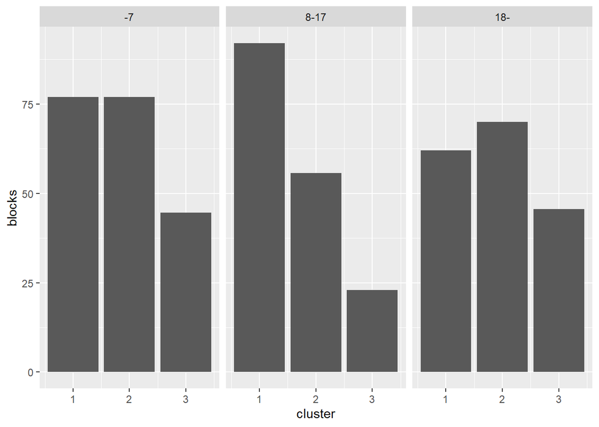

```r
learning19 %>%
  ggplot(aes(cluster, blocks)) +
  geom_col() +
  facet_wrap(~studylength_group)
```

### 3.2

Using cluster_blocks_stats, plot a bar plot that has **cluster** on the x-axis, **mean score** of blocks on the y-axis, and **studylength levels** in subplots (facets).

Use `geom_errorbar()` to add error bars that represent standard errors of the mean.

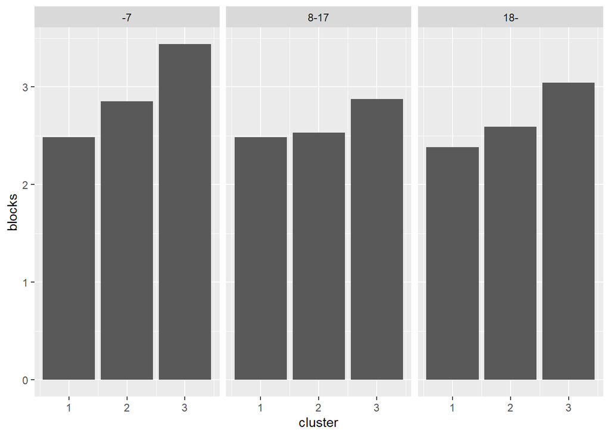

```r
learning19 %>%
  ggplot(aes(cluster, blocks)) +
  geom_bar(stat = "summary", fun.data = "mean_se") +
  facet_wrap(~studylength_group)
```

```r
  stat_summary(geom = "errorbar", fun.data = "mean_se")
```

```
## geom_errorbar: na.rm = FALSE, orientation = NA
## stat_summary: fun.data = mean_se, fun = NULL, fun.max = NULL, fun.min = NULL, fun.args = list(), na.rm = FALSE, orientation = NA
## position_identity
```

## Exercise 4 Boxplots

### 4.1

Create a figure that has boxplots of **cluster** (x-axis) by **blocks** (y-axis).

**Note:** What does ‘Ord.factor’ mean? I do not know how to change the type of the variable **cluster**.

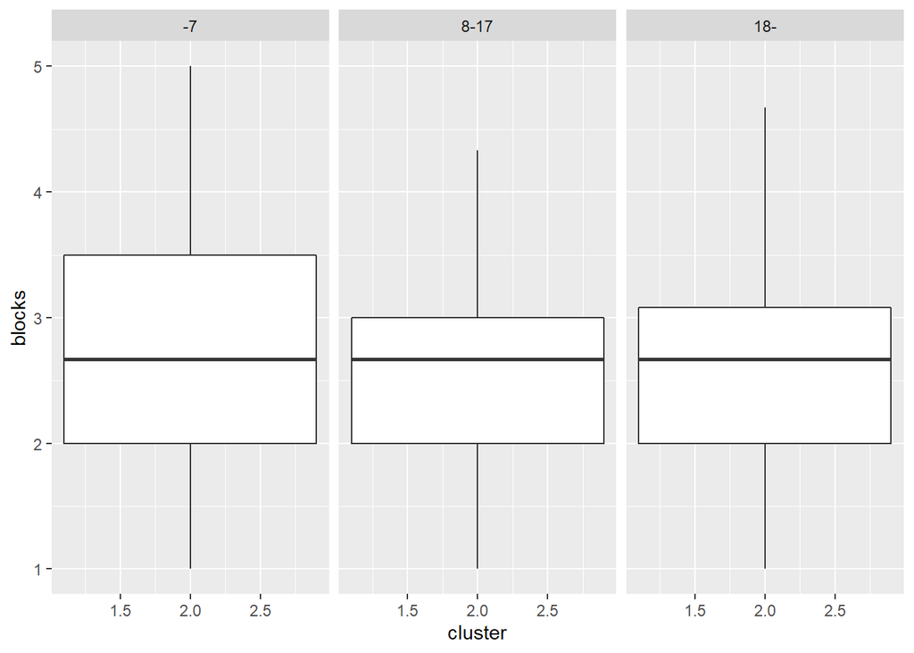

```r
learning19 %>%
  ggplot(aes(cluster, blocks)) +
  geom_boxplot() +
  facet_wrap(~studylength_group)
```

### 4.2

Group the data by cluster and add mean score of blocks by cluster to a new column **mean_score**. Do this with **`mutate()`** (not `summarise()`).

Reorder the levels of cluster based on mean_score.

**Hint**: Remember to ungroup after creating the mean_score variable.

**Note:** Maybe such types of the variables in my data is not suitable for these operation.

## Exercise 5

Using the data you modified in exercise 4.2, plot **mean scores** (x-axis) by **cluster** (y-axis) as points. The clusters should be ordered by mean score.

Use `stat_summary()` to add error bars that represent standard errors of the mean.

**Hint**: Be careful which variable - mean_score or score - you’re plotting in each of the geoms.

**Note:** Maybe the variables in my data is not suitable for such operation.